# TÜİK Kurumsal

HABER BÜLTENİ

**YAYIM TARİHİ:** 05 Mart 2021

**SAAT:** 10:00

**SAYI:** 37221

| **TEKNİK BİLGİ** Dilek GÜDER | \| | **BİLGİ TALEBİ** Bilgi Dağıtım Grup Başkanlığı |
| --- | --- | --- |
| +90 312 454 78 70 |  | ALO 124 |
| dilek.guder@tuik.gov.tr |  | bilgi@tuik.gov.tr |
| /tuikbilgi | \| | /tuikbilgi |

İstatistiklerle Kadın, 2020

**Türkiye nüfusunun %49,9'unu kadınlar, %50,1'ini erkekler oluşturdu**

Adrese Dayalı Nüfus Kayıt Sistemi (ADNKS) sonuçlarına göre; 2020 yılında, kadın nüfus 41 milyon 698 bin 377 kişi, erkek nüfus 41 milyon 915 bin 985 kişi oldu. Diğer bir ifadeyle; toplam nüfusun %49,9'unu kadınlar, %50,1'ini ise erkekler oluşturdu. Kadınlar ile erkekler arasındaki bu oransal denge, kadınların daha uzun yaşaması nedeniyle, 60 ve daha yukarı yaş grubundan itibaren kadınların lehine değişti. Kadın nüfusun oranı, 60-74 yaş grubunda %52,3 iken 90 ve üzeri yaş grubunda %73,4 oldu.

**Cinsiyete ve yaş grubuna göre nüfus oranı (%), 2020**

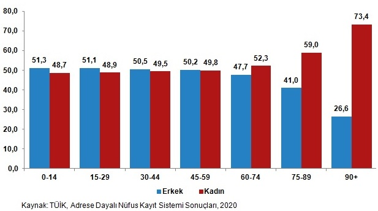

**Doğuşta beklenen yaşam süresi kadınlarda 81,3 yıl, erkeklerde 75,9 yıl oldu**

Hayat tabloları, 2017-2019 sonuçlarına göre; doğuşta beklenen yaşam süresi, Türkiye geneli için toplamda 78,6 yıl, kadınlarda 81,3 yıl, erkeklerde 75,9 yıl oldu. Genel olarak kadınlar erkeklerden daha uzun süre yaşamakta olup doğuşta beklenen yaşam süresi farkı 5,4 yıldır.

**Doğuşta sağlıklı yaşam süresi kadınlarda 55,4 yıl, erkeklerde 59,1 yıl oldu**

**En az bir eğitim düzeyini tamamlayan kadınların oranı %85,7 oldu**

Ulusal Eğitim İstatistikleri Veri Tabanı sonuçlarına göre; 2008-2019 yılları arasında, 25 ve daha yukarı yaşta olan ve en az bir eğitim düzeyini tamamlayanların toplam nüfus içindeki oranının yıllar itibarıyla arttığı görüldü. En az bir eğitim düzeyini tamamlayan 25 ve daha yukarı yaştaki bireylerin toplam nüfus içindeki oranı, 2008 yılında %81,1 iken 2019 yılında %91,0 oldu. En az bir eğitim düzeyini tamamlayanların oranı cinsiyete göre incelendiğinde; 2008 yılında, kadınlarda %72,6, erkeklerde %89,8 olan bu oran, 2019 yılında sırasıyla %85,7 ve %96,4 oldu.

**Cinsiyete göre en az bir eğitim düzeyini tamamlayanların oranı (%), 2008-2019**

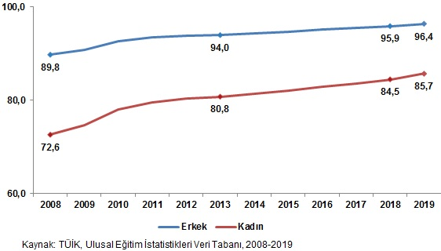

En az üniversite mezunu olan 25 ve daha yukarı yaştaki nüfusun toplam nüfus içindeki oranı ise 2008 yılında %9,8 iken 2019 yılında %20,8 oldu. Bu oran cinsiyete göre incelendiğinde; 2008 yılında 25 ve daha yukarı yaşta olup en az üniversite mezunu olan kadınların oranı %7,6, erkeklerin oranı %12,1 iken bu oran 2019 yılında kadınlarda %18,5, erkeklerde ise %23,1 oldu.

**Cinsiyete göre seçilmiş göstergeler, 2019**

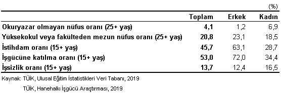

**Kadınların istihdam oranının erkeklerin yarısından daha az olduğu görüldü**

Hanehalkı işgücü araştırması sonuçlarına göre; 2019 yılında, Türkiye'de 15 ve daha yukarı yaştaki istihdam edilenlerin oranı %45,7 olup bu oran kadınlarda %28,7, erkeklerde ise %63,1 oldu.  
En yüksek istihdam oranı, 2019 yılında %53,0 ile TR21 (Tekirdağ, Edirne, Kırklareli) bölgesinde gerçekleşti. En düşük istihdam oranı ise %30,0 ile TRC3 (Mardin, Batman, Şırnak, Siirt) bölgesinde oldu. En yüksek kadın istihdam oranı, %38,6 ile TR90 (Trabzon, Ordu, Giresun, Rize, Artvin, Gümüşhane) bölgesinde iken en yüksek erkek istihdam oranı, %71,3 ile TR21 (Tekirdağ, Edirne, Kırklareli) bölgesinde gerçekleşti. En düşük istihdam oranı ise kadınlarda %12,4, erkeklerde %49,4 ile TRC3 (Mardin, Batman, Şırnak, Siirt) bölgesinde oldu.

**Hanesinde 3 yaşın altında çocuğu olan 25-49 yaş grubundaki kadın istihdam oranı %26,7 oldu**

Hanehalkı işgücü araştırması sonuçlarına göre; hanesinde 3 yaşın altında çocuğu olan 25-49 yaş grubundaki bireylerin istihdam oranı, 2014 yılında %59,8 iken 2019 yılında %58,7 oldu. Bu oran cinsiyete göre incelendiğinde; 2019 yılında hanesinde 3 yaşın altında çocuğu olan 25-49 yaş grubundaki kadınların istihdam oranının %26,7, erkeklerin istihdam oranının ise %87,3 olduğu görüldü.

Çalışma hayatında kalma süresi, bir kişinin hayatı boyunca işgücü piyasasında aktif olması beklenen yıl sayısı olarak tanımlanır. Hanehalkı işgücü araştırması sonuçlarına göre; çalışma hayatında kalma süresi, 2013 yılında 15 ve daha yukarı yaştaki kadınlarda 16,7 yıl, erkeklerde 37,7 yıl iken 2019 yılında çalışma hayatında kalma süresi kadınlarda 19,1 yıl, erkeklerde 39,0 yıl oldu.

**Çalışma hayatı süresi, 2013-2019**

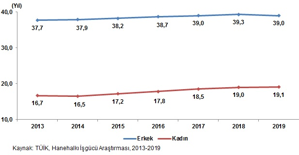

**Çalışan kadınların %64,6'sının işe geliş gidiş için harcanan zamandan memnun olduğu görüldü**

Yaşam memnuniyeti araştırması sonuçlarına göre; 2020 yılında çalışanların %62,0'ı işe geliş gidiş için harcanan zamandan memnun olduğunu belirtirken kadın çalışanlarda bu oranın %64,6, erkek çalışanlarda ise %61,0 olduğu görüldü.

**Kadın büyükelçi oranı %25,0 oldu**

Dışişleri Bakanlığı verilerine göre; kadın büyükelçi oranı 2007 yılında %9,4 iken bu oran 2020 yılında %25,0 oldu. Erkek büyükelçi oranı ise 2007 yılında %90,6 iken 2020 yılında %75,0 oldu.

**Kadın milletvekili oranı %17,3 oldu**

Türkiye Büyük Millet Meclisi verilerine göre; 2020 yılında 584 milletvekili içerisinde kadın milletvekili sayısının 101, erkek milletvekili sayısının ise 483 olduğu görüldü. Meclise giren kadın milletvekili oranı, 2007 yılında %9,1 iken bu oran 2020 yılında %17,3 oldu

**Ortalama ilk evlenme yaşı kadınlarda 25,1, erkeklerde 27,9 oldu**

Evlenme istatistiklerine göre; resmi olarak ilk evliliğini 2020 yılında yapmış olan kadınların ortalama evlenme yaşı 25,1 iken erkeklerin ortalama evlenme yaşı 27,9 oldu. Ortalama ilk evlenme yaşının en yüksek olduğu il, kadınlarda 27,6 yaş, erkeklerde 31,3 yaş ile Tunceli oldu. Ortalama ilk evlenme yaşının en düşük olduğu iller ise kadınlarda 22,2 yaş ile Ağrı, erkeklerde 26,0 yaş ile Şanlıurfa oldu.

**En yüksek ve en düşük ortalama ilk evlenme yaşına sahip ilk 3 ilin cinsiyete göre dağılımı, 2020**

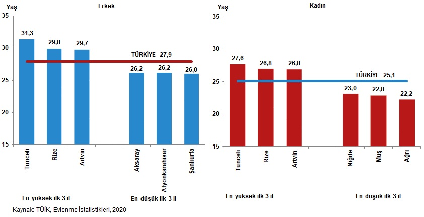

**Kadınların %15,1'inin eğitim seviyelerinin eşlerinden daha yüksek olduğu görüldü**

ADNKS sonuçlarına göre; resmi evliliklerde eşler arasındaki eğitim farkı incelendiğinde, 2019 yılında kadınların %40,4'ünün kendilerinden daha yüksek eğitimli erkeklerle evli olduğu, eşlerinden daha yüksek eğitimli olan kadınların oranının ise %15,1 olduğu görüldü. Eğitim seviyeleri aynı olan eşlerin oranı %42,9, eğitim seviyeleri farkı bilinmeyen eşlerin oranı ise %1,6 oldu.

**Kaba boşanma hızı binde 1,62 oldu**

Boşanma istatistiklerine göre; 2020 yılında kaba boşanma hızı binde 1,62 oldu. İllere göre incelendiğinde; kaba boşanma hızının en yüksek olduğu il, binde 2,47 ile Antalya oldu. Bu ili binde 2,45 ile İzmir, binde 2,40 ile Muğla izledi. Kaba boşanma hızının en düşük olduğu il ise binde 0,24 ile Hakkari oldu. Bu ili binde 0,25 ile Muş ve binde 0,29 ile Şırnak izledi.

**İnternet üzerinden ürün siparişi veren ya da satın alan kadınların oranı %32,7 oldu**

Hanehalkı bilişim teknolojileri kullanım araştırması sonuçlarına göre; internet üzerinden kişisel kullanım amacıyla mal veya hizmet siparişi veren ya da satın alan 16-74 yaş grubundaki bireylerin oranı, 2019 yılı Nisan ayı ile 2020 yılı Mart ayını kapsayan on iki aylık dönemde %36,5 oldu. Cinsiyete göre internet üzerinden mal veya hizmet siparişi verme ya da satın alma oranı, kadınlarda %32,7 iken erkeklerde %40,2 oldu.

**Kadınlarda obezite oranı %24,8 oldu**  
Türkiye sağlık araştırması sonuçlarına göre; boy ve kilo değerleri kullanılarak hesaplanan vücut kitle indeksi incelendiğinde; 15 yaş ve üstü obez bireylerin oranı 2008 yılında %15,2 iken, 2019 yılında %21,1'e yükseldi. Obez bireylerin oranı cinsiyet ayırımında incelendiğinde, 2019 yılında kadınların %24,8'inin, erkeklerin ise %17,3'ünün obez olduğu görüldü.

**Her gün tütün kullanan kadınların oranı %14,9 oldu**

Türkiye sağlık araştırması sonuçlarına göre; her gün tütün kullanan 15 yaş ve üstü bireylerin oranı 2010 yılında %25,4 iken 2019 yılında %28,0 oldu. Tütün kullanan bireylerin oranı cinsiyet ayrımında incelendiğinde, 2019 yılında kadınların %14,9'unun, erkeklerin %41,3'ünün her gün tütün kullandığı görüldü.

**Kadınlar en fazla dolaşım sistemi hastalıkları nedeniyle yaşamını yitirdi**

Ölüm ve ölüm nedeni istatistikleri sonuçlarına göre; 2019 yılında Türkiye genelinde ölüm nedenleri incelendiğinde ilk sırada %36,8 ile dolaşım sistemi hastalıkları yer alırken, ikinci sırada %18,4 ile iyi ve kötü huylu tümörler, üçüncü sırada ise %12,9 ile solunum sistemi hastalıkları yer aldı. Yaşamını yitiren kadınlar ve erkekler için ilk üç sıradaki ölüm nedenlerinin değişmediği görüldü.  
Dolaşım sistemi hastalıkları nedeniyle yaşamını yitirenlerin %49,8'inin kadın, %50,2'sinin erkek, iyi ve kötü huylu tümörlerden yaşamını yitirenlerin %35,5'inin kadın, %64,5'inin erkek, solunum sistemi hastalıkları nedeniyle yaşamını yitirenlerin %43,5'inin kadın, %56,5'inin erkek olduğu görüldü.

**Kadınların %27,3'ü yaşadığı çevrede gece yalnız yürürken kendini güvensiz hissetti**

Yaşam memnuniyeti araştırması sonuçlarına göre; 2020 yılında yaşadıkları çevrede gece yalnız yürürken kendilerini güvensiz hissedenlerin oranı toplamda %19,1 iken bu oran kadınlarda %27,3, erkeklerde %10,7 oldu. Kadınların %48,7'si, erkeklerin ise %69,9'u yaşadıkları çevrede kendilerini güvende hissetti.  
Evde yalnız otururken kendilerini güvensiz hissedenlerin oranı 2020 yılında toplamda %4,8, kadınlarda %6,2, erkeklerde %3,4 oldu. Kadınların %78,3'ü, erkeklerin ise %85,4'ü evde yalnız otururken kendilerini güvende hissetti.

Bu konuyla ilgili bir sonraki haber bülteninin yayımlanma tarihi Mart 2022'dir.  
__________________________________________________________________________________________________

**AÇIKLAMALAR**

Kadınların sosyal ve ekonomik konumlarını iyileştirmek için sorumluluğu bulunan tüm taraflarca çalışmalar yapılması ve olumsuz göstergelerin işaret ettiği alanlarda iyileştirilmelerin yapılması gerekliliği bir gerçektir. Bu alanda gerekli politikaların oluşturulması ve oluşturulan politikaların sağlıklı bir şekilde izlenebilmesi amacıyla, Türkiye İstatistik Kurumu (TÜİK) web sayfasında 16 başlık altında 141 göstergeyi içeren Toplumsal Cinsiyet Göstergeleri Veri Seti yayımlanmaktadır.  
Bununla birlikte, Birleşmiş Milletler (BM) Toplumsal Cinsiyet Göstergeleri Minimum Gösterge Seti de TÜİK web sayfasından sunulmaktadır. BM İstatistik Komisyonu tarafından 2013 yılında kabul edilen BM Toplumsal Cinsiyet Göstergeleri 52 Minimum Gösterge Seti, toplumsal cinsiyet istatistikleri konusunda, ulusal düzeyde üretilen ve uluslararası düzeyde karşılaştırılabilirliği olan göstergelerdir.

Tablolar

Tablo-1 Cinsiyete ve yaş grubuna göre nüfus

Tablo-2 Cinsiyete göre Türkiye tek yaş hayat tablosu

Tablo-3 Cinsiyete ve yaş grubuna göre Türkiye'de sağlıklı yaşam süresi

Tablo-4 Cinsiyete göre 25 yaş ve üstü nüfusta en az ilkokul mezunu olanların oranı

Tablo-5 Cinsiyete göre 25 yaş ve üstü nüfusta en az üniversite mezunu olanların oranı

Tablo-6 Cinsiyete göre bitirilen son öğrenim kurumu

Tablo-7 Cinsiyete ve eğitim durumuna göre işgücü durumu

Tablo-8 Cinsiyete ve İBBS 2. Düzeye göre istihdam oranı

Tablo-9 Cinsiyete göre 25-49 yaş grubunda olup hanehalkında 3 yaşın altında çocuğu olan ve çocuğu olmayan bireylerin istihdam oranları

Tablo-10 Çalışma hayatı süresi

Tablo-11 İşe geliş gidiş için harcanan zamandan memnuniyet

Tablo-12 Cinsiyete göre büyükelçi sayısı ve oranı

Tablo-13 Cinsiyete göre milletvekili sayısı ve Meclisteki temsil oranı

Tablo-14 İllere göre ortalama ilk evlenme yaşı

Tablo-15 Evli kadınların yaş grubu ve eğitim seviyesine göre eşleri ile aralarındaki eğitim farkının yüzde dağılımı

Tablo-16 İllere göre kaba boşanma hızı

Tablo-17 En son alışveriş zamanına ve cinsiyete göre bireylerin kişisel kullanım amacıyla İnternet üzerinden mal veya hizmet siparişi verme ya da satın alma oranı

Tablo-18 Bireylerin vücut kitle indeksinin cinsiyete göre dağılımı

Tablo-19 Bireylerin tütün mamulü kullanma durumunun cinsiyet ve yaş grubuna göre dağılımı

Tablo-20 Seçilmiş ölüm nedeni, cinsiyet ve yaş grubuna göre ölümler

Tablo-21 Cinsiyete göre bireylerin yaşadığı çevrede gece yalnız yürürken kendini güvende hissetme durumu

Tablo-22 Cinsiyete göre bireylerin kendini evinde yalnızken güvende hissetme durumu

Tablolar ve Bülteni İndir

Raporlar

Bültene ait rapor bulunmamaktadır.

İstatistiksel Tablolar

[output not shown]